In this experiment I explore other ways than Salmon to quantify the mapped reads at gene level to find out whether the choice of quantifying method has an impact on the results. In all cases STAR was used to map the sequence reads to the reference genome, DESeq for differential expression analysis and clusterProfiler for gene set enrichment analysis.

The following tables and plots show the list of over-representated KEGG pathways and the top biological processes that are enriched in the differentially expressed genes using Htseq and STAR quantmode for gene quantification across the samples.

**Over-representated KEGG pathways in the wild type samples**

Htseq

| Description | GeneRatio | p.adjust |
| --- | --- | --- |
| Cytokine-cytokine receptor interaction | 49/637 | 0.0000000 |
| Viral protein interaction with cytokine and cytokine receptor | 19/637 | 0.0000122 |
| Staphylococcus aureus infection | 16/637 | 0.0003103 |
| Neuroactive ligand-receptor interaction | 36/637 | 0.0037183 |
| JAK-STAT signaling pathway | 26/637 | 0.0037183 |
| IL-17 signaling pathway | 20/637 | 0.0078108 |
| Hematopoietic cell lineage | 14/637 | 0.0114794 |
| ECM-receptor interaction | 18/637 | 0.0114794 |
| Asthma | 6/637 | 0.0174616 |
| Rheumatoid arthritis | 15/637 | 0.0374887 |

STAR --quantMode GeneCounts option

| Description | GeneRatio | p.adjust |
| --- | --- | --- |
| Cytokine-cytokine receptor interaction | 44/587 | 0.0000000 |
| Viral protein interaction with cytokine and cytokine receptor | 16/587 | 0.0001858 |
| Staphylococcus aureus infection | 13/587 | 0.0024755 |
| Neuroactive ligand-receptor interaction | 32/587 | 0.0029229 |
| Transcriptional misregulation in cancer | 28/587 | 0.0107754 |
| Rheumatoid arthritis | 15/587 | 0.0224425 |
| JAK-STAT signaling pathway | 22/587 | 0.0391034 |
| IL-17 signaling pathway | 17/587 | 0.0437949 |

The resulting lists of over-represented KEGG pathways only partially overlap with each other and with the original list using Salmon for read mapping and gene quantification. In all of the three lists the following pathways are present:

- Cytokine-cytokine receptor interaction
- Viral protein interaction with cytokine and cytokine receptor
- Staphylococcus aureus infection
- IL-17 signaling pathway

In addition, the following pathways are found to be over-respresented in the analyses using Htseq and STAR quantmode:

- Neuroactive ligand-receptor interaction
- JAK-STAT signaling pathway
- Rheumatoid arthritis

**Top 10 enriched biological processes in the wild type samples**

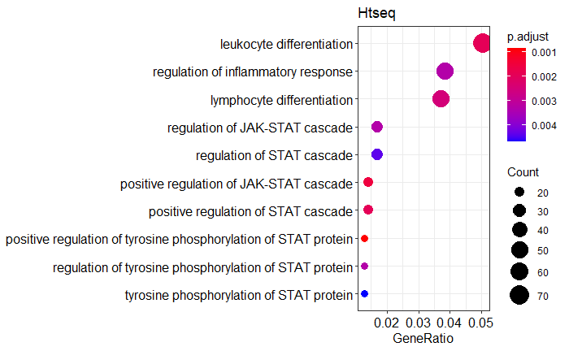

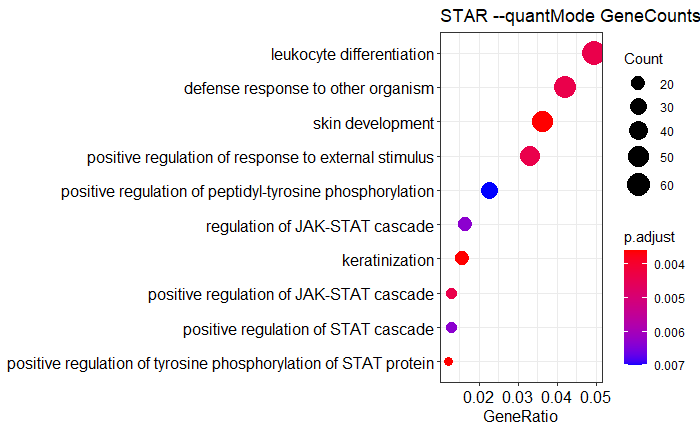

**Over-representated KEGG pathways in the mutant samples**

Htseq

| Description | GeneRatio | p.adjust |
| --- | --- | --- |
| Cytokine-cytokine receptor interaction | 66/778 | 0.0000000 |
| Viral protein interaction with cytokine and cytokine receptor | 26/778 | 0.0000004 |
| IL-17 signaling pathway | 26/778 | 0.0006214 |
| Hematopoietic cell lineage | 19/778 | 0.0050566 |
| Inflammatory bowel disease (IBD) | 16/778 | 0.0060329 |
| Asthma | 7/778 | 0.0060329 |
| Osteoclast differentiation | 26/778 | 0.0115724 |
| Toll-like receptor signaling pathway | 23/778 | 0.0115724 |
| TNF signaling pathway | 27/778 | 0.0115724 |
| Neuroactive ligand-receptor interaction | 42/778 | 0.0124856 |
| Influenza A | 31/778 | 0.0173654 |
| Staphylococcus aureus infection | 15/778 | 0.0173654 |
| Malaria | 11/778 | 0.0187999 |
| Rheumatoid arthritis | 18/778 | 0.0397059 |
| NF-kappa B signaling pathway | 22/778 | 0.0424830 |
| JAK-STAT signaling pathway | 27/778 | 0.0424830 |

STAR --quantMode GeneCounts option

| Description | GeneRatio | p.adjust |
| --- | --- | --- |
| Cytokine-cytokine receptor interaction | 60/708 | 0.0000000 |
| Viral protein interaction with cytokine and cytokine receptor | 24/708 | 0.0000008 |
| IL-17 signaling pathway | 27/708 | 0.0000192 |
| Toll-like receptor signaling pathway | 26/708 | 0.0003167 |
| TNF signaling pathway | 29/708 | 0.0003739 |
| Asthma | 7/708 | 0.0011707 |
| Hematopoietic cell lineage | 18/708 | 0.0013422 |
| Osteoclast differentiation | 26/708 | 0.0022447 |
| Inflammatory bowel disease (IBD) | 15/708 | 0.0039781 |
| Influenza A | 30/708 | 0.0064532 |
| RIG-I-like receptor signaling pathway | 17/708 | 0.0064532 |
| Neuroactive ligand-receptor interaction | 37/708 | 0.0075369 |
| Cytosolic DNA-sensing pathway | 15/708 | 0.0099007 |
| NF-kappa B signaling pathway | 22/708 | 0.0145076 |
| Autoimmune thyroid disease | 8/708 | 0.0215508 |
| JAK-STAT signaling pathway | 26/708 | 0.0245184 |
| Rheumatoid arthritis | 17/708 | 0.0245184 |
| Measles | 25/708 | 0.0245184 |
| Malaria | 10/708 | 0.0286167 |
| Staphylococcus aureus infection | 13/708 | 0.0288477 |
| Intestinal immune network for IgA production | 9/708 | 0.0339098 |
| Vitamin digestion and absorption | 7/708 | 0.0369364 |

In this case a larger portion of the over-represented KEGG-pathways overlap between the three analytical methods which are the following:

- Cytokine-cytokine receptor interaction
- Viral protein interaction with cytokine and cytokine receptor
- IL-17 signaling pathway
- Hematopoietic cell lineage
- Inflammatory bowel disease (IBD)
- Asthma
- TNF signaling pathway
- Neuroactive ligand-receptor interaction
- Staphylococcus aureus infection
- Malaria
- NF-kappa B signaling pathway
- JAK-STAT signaling pathway

All the remainig pathways in the list of Htseq are present in the over-represented list of STAR quantmode:

- Osteoclast differentiation
- Toll-like receptor signaling pathway
- Influenza A
- Rheumatoid arthritis"

**Top 10 enriched biological processes in TRIM 28 6KR mutant data**

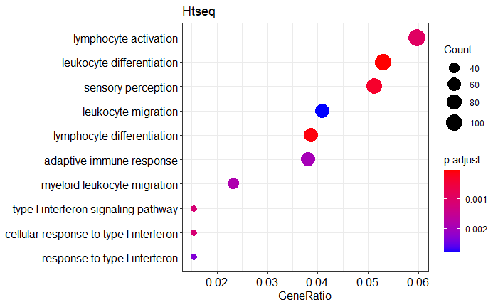

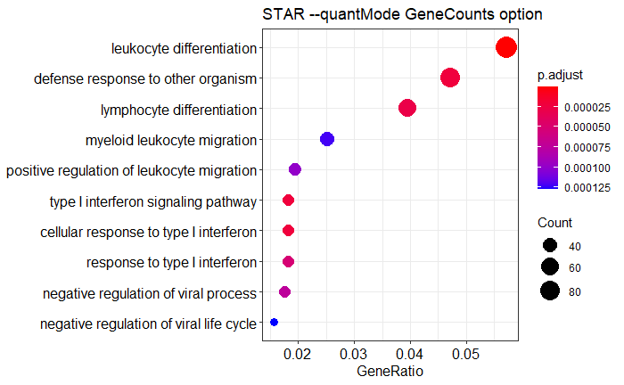

The enriched biological processes that are pesent in all three top lists are the following:

- leukocyte differentiation
- myeloid leukocyte migration
- type I interferon signaling pathway
- cellular response to type I interferon
- response to type I interferon

In this case the results were closer between the lists produced by Salmon and STAR quantmode, where 8 processes out of the top 10 are the same. All three lists show greater response to viral infection than the samples with the wild type genes meeting our expectation as in the mutant cells the interferon transcription is not regulated negatively.

In the following plots I compare the genes’ counts in the first sample (run ID of the experiment: SRR9602253) resulted by the different methods to see whether there is a significant difference between them that could have resulted this deviation.

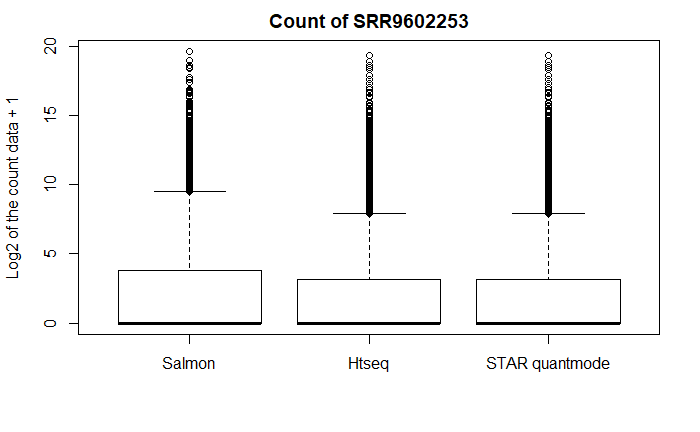

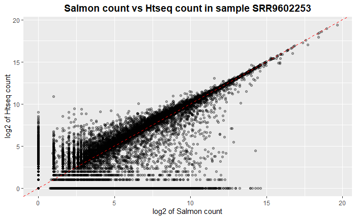

```
Cannot compute exact p-value with ties
```

```
    Spearman's rank correlation rho

data:  joined_1$SRR9602253_salmon and joined_1$SRR9602253_htseq
S = 5.4712e+12, p-value < 2.2e-16
alternative hypothesis: true rho is not equal to 0
sample estimates:
      rho
0.8498323
```

The Spearman’s correlation coefficient is 0.8498323 with a low p-value indicating positive correlation between the two datasets, however the datasets are not identical. Based on the plot above Htseq resulted in higher count number in general.

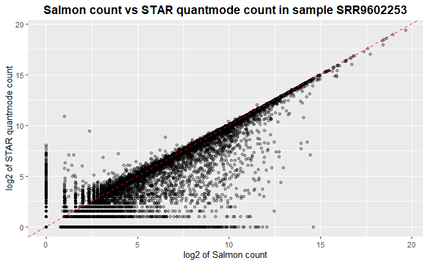

```
Cannot compute exact p-value with ties
```

```
    Spearman's rank correlation rho

data:  joined_1$SRR9602253_salmon and joined_1$SRR9602253_quant
S = 3.1507e+12, p-value < 2.2e-16
alternative hypothesis: true rho is not equal to 0
sample estimates:
      rho
0.9135216
```

The Spearman’s correlation coefficient is 0.9135216 with low p-value showing a greater correlation between Salmon and STAR quantmode counts than between Salmon and Htseq. In this case Salmon counts were higher in general compared to the STAR quantmode result.

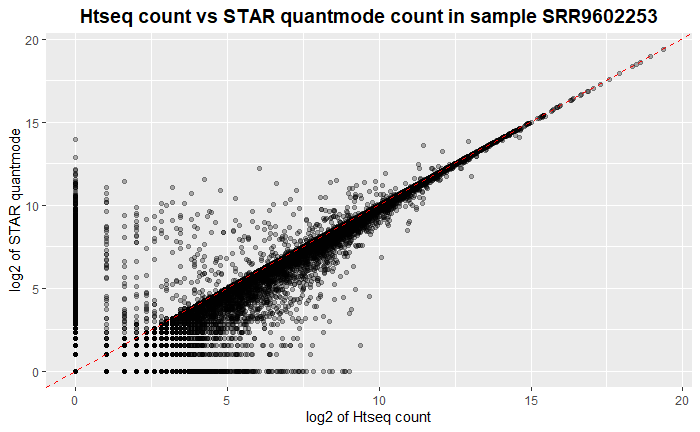

```
Cannot compute exact p-value with ties
```

```
    Spearman's rank correlation rho

data:  joined_1$SRR9602253_htseq and joined_1$SRR9602253_quant
S = 3.61e+12, p-value < 2.2e-16
alternative hypothesis: true rho is not equal to 0
sample estimates:
      rho
0.9009173
```

The Spearman’s correlation is 0.9009173 with low p-value showing great correlation between the count groups above.

The difference in the count numbers produced by the three different methods migth be explained by the different approaches of these software: Salmon uses “quasi-mapping” quantifying the reads at transcript level while STAR uses alignment-dependent mapping. With Htseq and STAR quantmode the genes were quantified at gene level and while in the event of a read mapping to multiple features the read was discarded with these software, it was counted proportionally with Salmon.

Based on the STAR manual: “With –quantMode GeneCounts option STAR will count number reads per gene while mapping. A read is counted if it overlaps (1nt or more) one and only one gene. Both ends of the pairedend read are checked for overlaps. The counts coincide with those produced by htseq-count with default parameters.” [Alexander Dobin: STAR manual.pdf](https://github.com/alexdobin/STAR/blob/master/doc/STARmanual.pdf)

The difference in count numbers between STAR quantmode and Htseq in this case might origin in the different settings of the two quantification methods.